# Indel Signature InsDel_D

# InsDel_D

**Note**

InsDel_D and InsDel_1a as extracted in the 89-type classification have cosine similarity of 0.91 and as extracted in the 476-type classification have cosine similarity of 0.95. On balance we think they are different because InsDel_D is enriched in MSIs and with obviously higher >=2bp insertions.

(corresponds to 83-type signature ID_D)

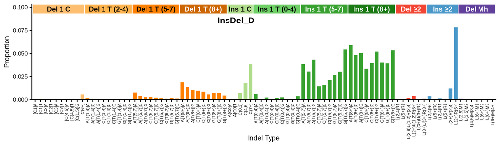

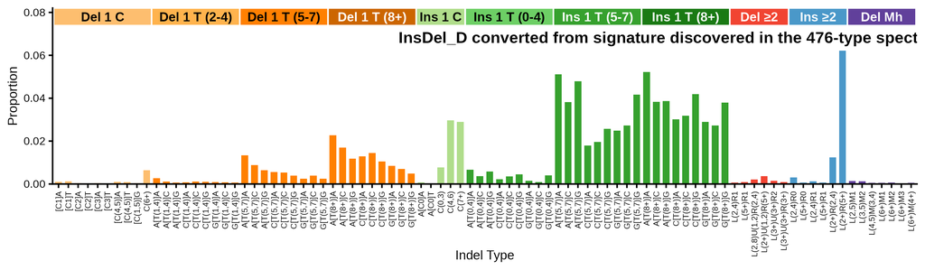

89-type spectrum of the linking tumor CPCT02100101T | cosine similarity to InsDel_D: 0.9879

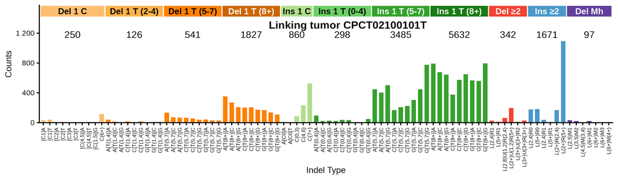

**Click to view decomposition of the linking tumor spectrum**

Partial mutation signature of CPCT02100101T due to InsDel_D

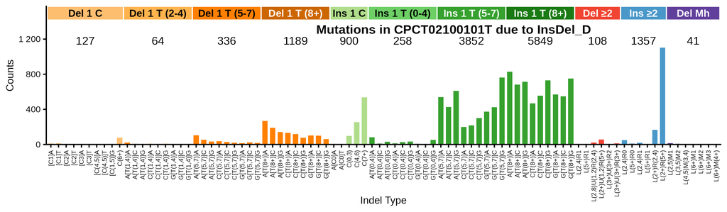

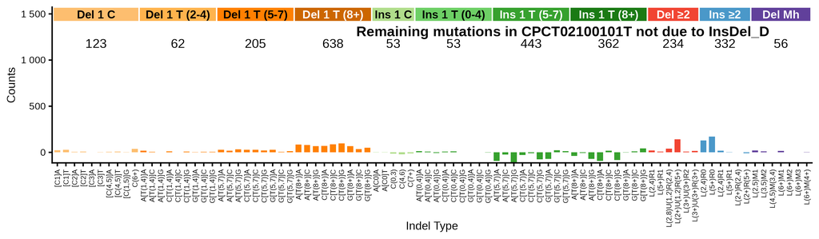

Max neg fraction (maximum allowed negative residual count as fraction of total): 0.05  
N subtract (mutation count assigned to signature): 14080.9  
N residual (mutation count in residual “partial spectrum”): 1048.1  
Total negative (sum of negative residual mutation counts): 756.4  
N negative channels (number of channels with negative residual): 19  
P(≥ total negative) (Monte Carlo estimated probability that negative-binomial-sampled spectra from the signature contributing N subtract mutations would produce a total negative count >= the observed Total negative; higher number means not surprising): 0.973

**Per-channel residual breakdown**

| Channel | Spectrum | Sig_Count | Residual | Sig_Prop |
| --- | --- | --- | --- | --- |
| [Del(C):R1]A | 33 | 10.2 | 22.8 | 0.00073 |
| [Del(C):R1]T | 41 | 13.5 | 27.5 | 0.00096 |
| [Del(C):R2]A | 11 | 5.0 | 6 | 0.00035 |
| [Del(C):R2]T | 13 | 4.9 | 8.1 | 0.00035 |
| [Del(C):R3]A | 3 | 1.7 | 1.3 | 0.00012 |
| [Del(C):R3]T | 7 | 3.3 | 3.7 | 0.00024 |
| [Del(C):R(4,5)]A | 9 | 3.8 | 5.2 | 0.00027 |
| [Del(C):R(4,5)]T | 11 | 3.5 | 7.5 | 0.00025 |
| [Del(C):R(1,5)]G | 6 | 3.4 | 2.6 | 0.00024 |
| Del(C):R(6,9) | 116 | 78.2 | 37.8 | 0.00555 |
| A[Del(T):R(1,4)]A | 40 | 21.0 | 19 | 0.00149 |
| A[Del(T):R(1,4)]C | 14 | 7.2 | 6.8 | 0.00051 |
| A[Del(T):R(1,4)]G | 3 | 2.6 | 0.4 | 0.00019 |
| C[Del(T):R(1,4)]A | 18 | 8.0 | 10 | 0.00057 |
| C[Del(T):R(1,4)]C | 7 | 5.9 | 1.1 | 0.00042 |
| C[Del(T):R(1,4)]G | 18 | 8.5 | 9.5 | 0.00060 |
| G[Del(T):R(1,4)]A | 6 | 2.9 | 3.1 | 0.00021 |
| G[Del(T):R(1,4)]C | 10 | 3.6 | 6.4 | 0.00025 |
| G[Del(T):R(1,4)]G | 10 | 4.4 | 5.6 | 0.00031 |
| A[Del(T):R(5,7)]A | 134 | 105.8 | 28.2 | 0.00751 |
| A[Del(T):R(5,7)]C | 73 | 54.7 | 18.3 | 0.00388 |
| A[Del(T):R(5,7)]G | 67 | 34.3 | 32.7 | 0.00244 |
| C[Del(T):R(5,7)]A | 66 | 37.5 | 28.5 | 0.00266 |
| C[Del(T):R(5,7)]C | 57 | 28.8 | 28.2 | 0.00204 |
| C[Del(T):R(5,7)]G | 40 | 19.6 | 20.4 | 0.00139 |
| G[Del(T):R(5,7)]A | 43 | 14.3 | 28.7 | 0.00101 |
| G[Del(T):R(5,7)]C | 32 | 24.9 | 7.1 | 0.00177 |
| G[Del(T):R(5,7)]G | 29 | 16.3 | 12.7 | 0.00116 |
| A[Del(T):R(8,)]A | 352 | 267.1 | 84.9 | 0.01897 |
| A[Del(T):R(8,)]C | 270 | 189.0 | 81 | 0.01343 |

[output cut: 59 more lines]

**Click to view similar signatures from Koh et al.**

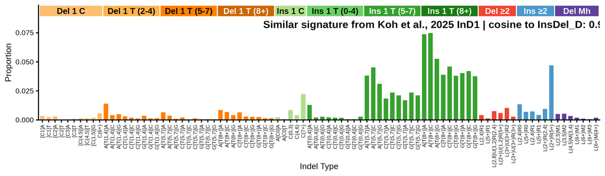

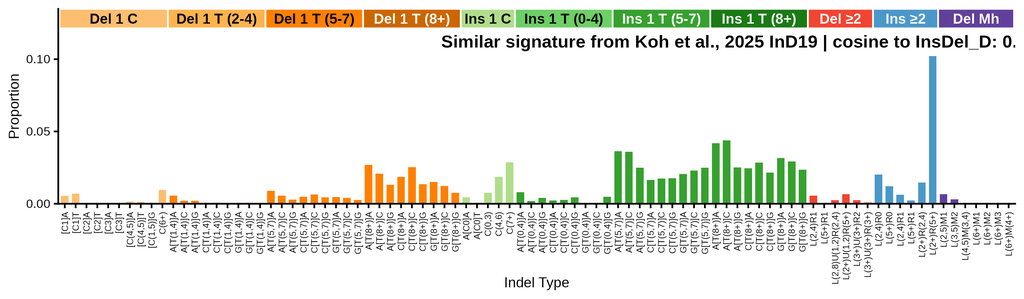

## 476-type representations corresponding to InsDel_D

Extracted 476-type signature corresponding to InsDel_D

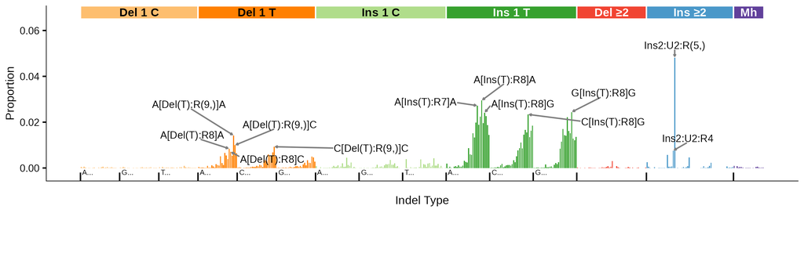

476-type spectrum of the linking tumor CPCT02100101T; cosine similarity to the extracted 476-type signature is 0.9587

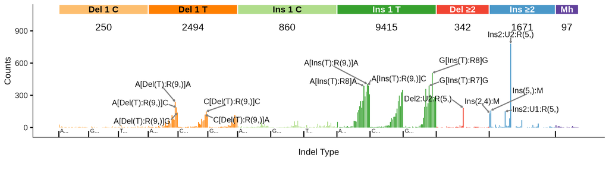

476-type spectrum of best 476-type matching tumor SP102133; cosine similarity to the extracted 476-type signature is 0.9997

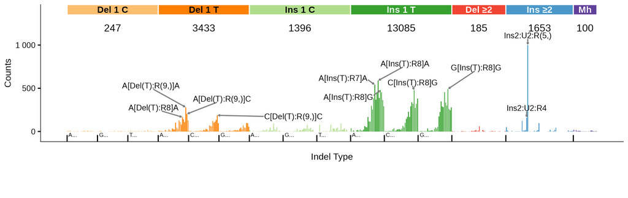

## 83-type signature corresponding to InsDel_D (ID_D)

**Note**

WARNING: The 83-type ID_D extraction excluded the large proportion of T insertions in long poly-T contexts that were detected in extractions in the 89-type and 476-type classifications. This accounts for the low cosine similarity between the 83-type signature ID_D and the 476-type signature collapsed to the 83-type classification.

In the plot of the 83-type signature converted from the extracted 476-type signature these account for 75% of mutations and the other mutation classes are barely visible.

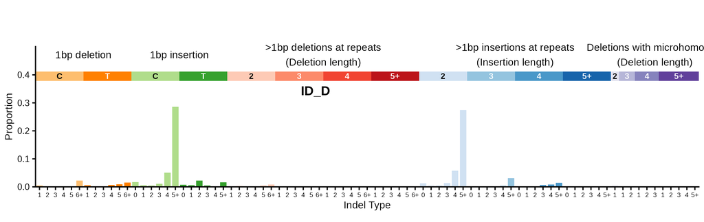

83-type signature converted from signature discovered in the 476-type spectra (using bipartite matching optimization) | cosine similarity to ID_D: 0.1632

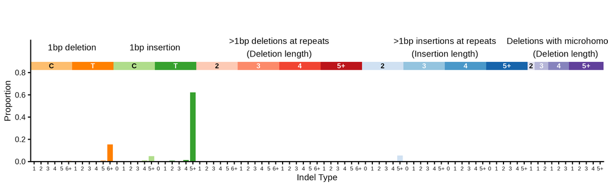

**Click here to see with insertions and deletions of T in long poly-T suppressed**

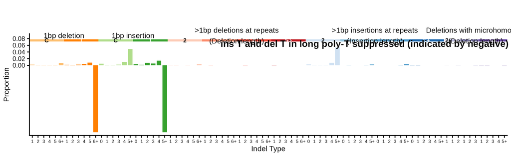

**Click to see flow diagrams: 476-type to 83-type collapse**

These Sankey diagrams show how the 476-type mutation categories are redistributed to 83-type categories using bipartite matching. We only show the diagrams for insertions or deletions of > 1 base because it is for these indels that 476-type categories map to > 1 83-type category.

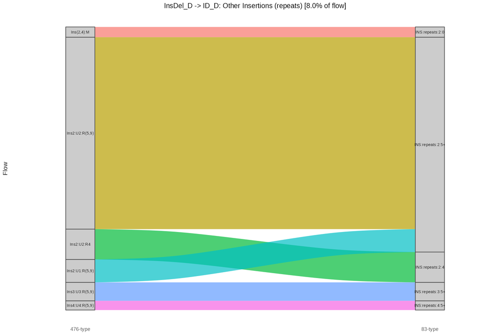

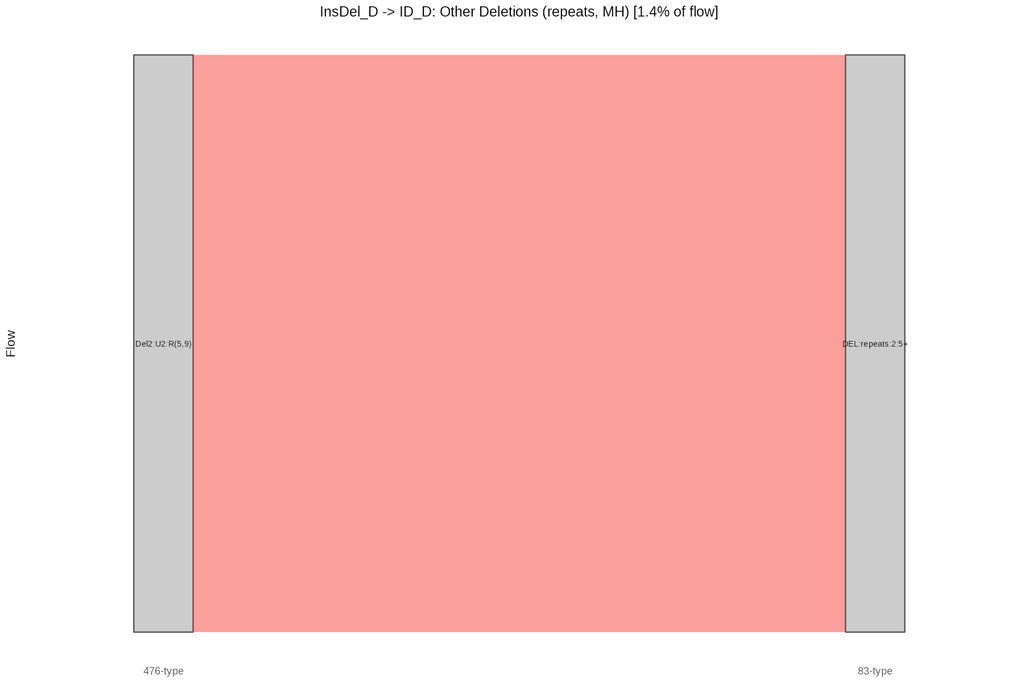

83-type spectrum of the linking tumor CPCT02100101T | cosine similarity to ID_D: 0.1608

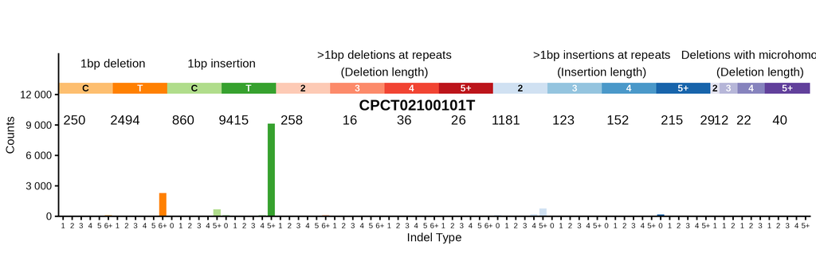

**Click here to see with insertions and deletions of T in long poly-T suppressed**

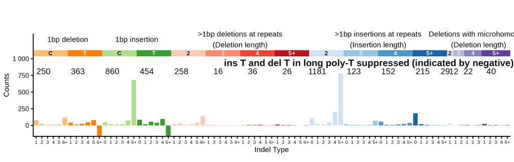

83-type spectrum of best 83-type matching tumor SP116834 | cosine similarity to ID_D: 0.4313

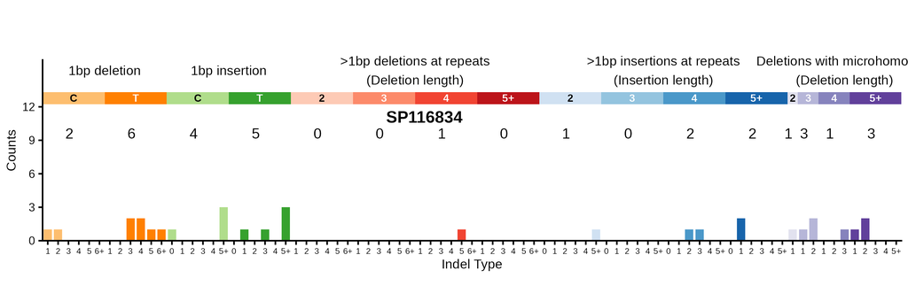